# Kaggle 타이타닉 생존자 예측

70%의 탑승객이 Southampton에서 탑승함. Embarked를 I() 함수를 이용하여 2차원으로 축소하여 처리

```r
set.seed(35)
glm.tune.2 <- train(Fate ~ Class + Sex + Age + Title + avg_prob + I(Embarked=="S")
                      ,data = train_batch_munged
                      , method = "glm"
                      ,metric = "ROC"
                      , trControl = cv.ctrl)
summary(glm.tune.2)
```

```
##
## Call:
## NULL
##
## Deviance Residuals:
##    Min      1Q  Median      3Q     Max
## -2.465  -0.527  -0.363   0.528   2.510
##
## Coefficients: (13 not defined because of singularities)
##                          Estimate Std. Error z value Pr(>|z|)
## (Intercept)               16.4832   618.7467    0.03   0.9787
## ClassSecond               -0.9400     0.3393   -2.77   0.0056 **
## ClassThird                -1.4255     0.3405   -4.19  2.8e-05 ***
## Sexmale                  -13.7742   618.7468   -0.02   0.9822
## Age                       -0.0299     0.0106   -2.83   0.0047 **
## TitleCol                       NA         NA      NA       NA
## TitleMajor                     NA         NA      NA       NA
## TitleSir                       NA         NA      NA       NA
## TitleLady                      NA         NA      NA       NA
## TitleRev                       NA         NA      NA       NA
## TitleDr                        NA         NA      NA       NA
## TitleDon                       NA         NA      NA       NA
## TitleJonkheer                  NA         NA      NA       NA
## `Titlethe Countess`            NA         NA      NA       NA
## TitleMrs                 -11.5780   618.7465   -0.02   0.9851
## TitleMs                        NA         NA      NA       NA
## TitleMr                    0.2400     0.5960    0.40   0.6872
## TitleMme                       NA         NA      NA       NA
## TitleMlle                      NA         NA      NA       NA
## TitleMiss                -12.3745   618.7465   -0.02   0.9840
## TitleMaster                1.1150     0.8183    1.36   0.1730
## TitleNoble                     NA         NA      NA       NA
## avg_prob                  -3.0873     0.5981   -5.16  2.4e-07 ***
## `I(Embarked == "S")TRUE`  -0.5588     0.2329   -2.40   0.0164 *
## ---
## Signif. codes:  0 '***' 0.001 '**' 0.01 '*' 0.05 '.' 0.1 ' ' 1
##
## (Dispersion parameter for binomial family taken to be 1)
##
##     Null deviance: 950.86  on 713  degrees of freedom
## Residual deviance: 588.06  on 703  degrees of freedom
## AIC: 610.1
##
## Number of Fisher Scoring iterations: 13
```

As I discussed earlier, the ‘Title’ feature addresses more than one theme. For that reason, I believe it has real potential to improve this model. Besides, I put a good chunk of effort into it, so why not give it a go?

Title에서 중요한 영향을 줄 수 있는 잠재력이 있어 보임

```r
set.seed(35)
glm.tune.3 <- train(Fate ~ Class + Sex + Age + Title + avg_prob + I(Embarked=="S")
                    , data = train_batch_munged
                    , method = "glm"
                    ,metric = "ROC"
                    , trControl = cv.ctrl)
summary(glm.tune.3)
```

```
##
## Call:
## NULL
##
## Deviance Residuals:
##    Min      1Q  Median      3Q     Max
## -2.465  -0.527  -0.363   0.528   2.510
##
## Coefficients: (13 not defined because of singularities)
##                          Estimate Std. Error z value Pr(>|z|)
## (Intercept)               16.4832   618.7467    0.03   0.9787
## ClassSecond               -0.9400     0.3393   -2.77   0.0056 **
## ClassThird                -1.4255     0.3405   -4.19  2.8e-05 ***
## Sexmale                  -13.7742   618.7468   -0.02   0.9822
## Age                       -0.0299     0.0106   -2.83   0.0047 **
## TitleCol                       NA         NA      NA       NA
## TitleMajor                     NA         NA      NA       NA
## TitleSir                       NA         NA      NA       NA
## TitleLady                      NA         NA      NA       NA
## TitleRev                       NA         NA      NA       NA
## TitleDr                        NA         NA      NA       NA
## TitleDon                       NA         NA      NA       NA
## TitleJonkheer                  NA         NA      NA       NA
## `Titlethe Countess`            NA         NA      NA       NA
## TitleMrs                 -11.5780   618.7465   -0.02   0.9851
## TitleMs                        NA         NA      NA       NA
## TitleMr                    0.2400     0.5960    0.40   0.6872
## TitleMme                       NA         NA      NA       NA
## TitleMlle                      NA         NA      NA       NA
## TitleMiss                -12.3745   618.7465   -0.02   0.9840
## TitleMaster                1.1150     0.8183    1.36   0.1730
## TitleNoble                     NA         NA      NA       NA
## avg_prob                  -3.0873     0.5981   -5.16  2.4e-07 ***
## `I(Embarked == "S")TRUE`  -0.5588     0.2329   -2.40   0.0164 *
## ---
## Signif. codes:  0 '***' 0.001 '**' 0.01 '*' 0.05 '.' 0.1 ' ' 1
##
## (Dispersion parameter for binomial family taken to be 1)
##
##     Null deviance: 950.86  on 713  degrees of freedom
## Residual deviance: 588.06  on 703  degrees of freedom
## AIC: 610.1
##
## Number of Fisher Scoring iterations: 13
```

앞서 우리는 ‘영자와 아이 우선’ 가설을 생성함, Title로 가설에 중요한 변수를 처리함

```r
 set.seed(35)
 glm.tune.4 <- train(Fate ~ Class + Sex + avg_prob
                     + I(Title=="Mr") + I(Title=="Noble") + Age + Family
                     + I(Embarked=="S")
                     ,data = train_batch_munged
                     ,method = "glm"
                     ,metric = "ROC"
                     , trControl = cv.ctrl)
 summary(glm.tune.4)
```

```
##
## Call:
## NULL
##
## Deviance Residuals:
##    Min      1Q  Median      3Q     Max
## -2.499  -0.523  -0.392   0.532   2.430
##
## Coefficients:
##                           Estimate Std. Error z value Pr(>|z|)
## (Intercept)                4.52943    0.48660    9.31  < 2e-16 ***
## ClassSecond               -0.97112    0.33524   -2.90   0.0038 **
## ClassThird                -1.57961    0.35113   -4.50  6.8e-06 ***
## Sexmale                   -0.04594    0.53242   -0.09   0.9312
## avg_prob                  -2.55063    0.62988   -4.05  5.1e-05 ***
## `I(Title == "Mr")TRUE`    -1.91904    0.60776   -3.16   0.0016 **
## `I(Title == "Noble")TRUE` -1.94918    0.76979   -2.53   0.0113 *
## Age                       -0.02631    0.00971   -2.71   0.0067 **
## Family                    -0.27651    0.08744   -3.16   0.0016 **
## `I(Embarked == "S")TRUE`  -0.44762    0.23563   -1.90   0.0575 .
## ---
## Signif. codes:  0 '***' 0.001 '**' 0.01 '*' 0.05 '.' 0.1 ' ' 1
##
## (Dispersion parameter for binomial family taken to be 1)
##
##     Null deviance: 950.86  on 713  degrees of freedom
## Residual deviance: 582.19  on 704  degrees of freedom
## AIC: 602.2
##
## Number of Fisher Scoring iterations: 5
```

Remember that there were a lot of male passengers in third class. Given the “women and children first” policy already mentioned plus reports that the Titanic’s internal layout was confusing (I recall reading that one crew member claimed it took him two weeks to become comfortable with finding his way around the ship), to say that “grown men in the lower decks had it tough” is such a gross understatement that I hesitated to put it in type. A feature reflecting those third-class men might make a further dent in that residual deviance. Indeed, it does…

’여자와 아이들 우선’의 가설을 검증하기 위하여 I()함수를 이용하여 몇 가지 피쳐를 추가

변수의 특정 조건 연산을 통해 feature를 추가 ..

```r
 set.seed(35)
 glm.tune.5 <- train(Fate ~ Class + Sex + avg_prob
                     + I(Title=="Mr") + I(Title=="Noble") + Age + Family
                     + I(Embarked=="S") + I(Title=="Mr"&Class=="Third")
                     , data = train_batch_munged
                     , method = "glm"
                     , metric = "ROC"
#                      , metric = "Accuracy"
                     , trControl = cv.ctrl)
 summary(glm.tune.5)
```

```
##
## Call:
## NULL
##
## Deviance Residuals:
##    Min      1Q  Median      3Q     Max
## -2.966  -0.561  -0.413   0.347   2.440
##
## Coefficients:
##                                           Estimate Std. Error z value Pr(>|z|)
## (Intercept)                                 5.9691     0.6911    8.64  < 2e-16 ***
## ClassSecond                                -1.5019     0.4439   -3.38  0.00072 ***
## ClassThird                                 -3.4364     0.6490   -5.29  1.2e-07 ***
## Sexmale                                    -0.0420     0.5558   -0.08  0.93969
## avg_prob                                   -2.2544     0.6855   -3.29  0.00101 **
## `I(Title == "Mr")TRUE`                     -3.6147     0.8109   -4.46  8.3e-06 ***
## `I(Title == "Noble")TRUE`                  -3.2936     0.9139   -3.60  0.00031 ***
## Age                                        -0.0293     0.0104   -2.82  0.00481 **
## Family                                     -0.2591     0.0916   -2.83  0.00468 **
## `I(Embarked == "S")TRUE`                   -0.4921     0.2339   -2.10  0.03539 *
## `I(Title == "Mr" & Class == "Third")TRUE`   2.3585     0.5951    3.96  7.4e-05 ***
## ---
## Signif. codes:  0 '***' 0.001 '**' 0.01 '*' 0.05 '.' 0.1 ' ' 1
##
## (Dispersion parameter for binomial family taken to be 1)
##
##     Null deviance: 950.86  on 713  degrees of freedom
## Residual deviance: 562.68  on 703  degrees of freedom
## AIC: 584.7
##
## Number of Fisher Scoring iterations: 6
```

```r
test.batch$new_predicted <- ''
test.batch$new_predicted <- predict(glm.tune.5, newdata=test.batch)
(glm.tune.5_accuracy <- sum(test.batch$new_predicted == test.batch$Fate) / NROW(test.batch$Fate) )
```

```
## [1] 0.86
```

```r
# @@@ 제출용 코드
# names(all2)
# head(all2)
# # str(all2)
# dim(all2)
#
# # ## 실제 Embarked 필드에서 null 값이 있는 행에 대해서 확인을
# # all2[!complete.cases(all2$Age),]
# # all2[!complete.cases(all2$Title),]
# # predict(glm.tune.5, newdata=all2, type="raw")
# #
# # require(Amelia)
# # missmap(all2, main="Titanic Training Data - Missings Map",
# #         col=c("yellow", "black"), legend=FALSE)
# #
#
# # all2$PassengerId
# all2$Survived <- ''
# all2$Survived <- predict(glm.tune.5, newdata=all2, type="raw")
# all2$Survived <- revalue(all2$Survived, c("Survived" = 1, "dead" = 0))
# head(all2)
# submission_01 <- all2[,c("PassengerId", "Survived")]
# setwd("C:\\Users\\user\\Documents\\eda\\submission")
# getwd()
# write.csv(submission_01, file = "test_glm_tune_01.csv", row.names=FALSE)
```

가장 낮은 AIC 도출 ..

# Other Models

지금까지 새로운 feature 를 생성해 보고, 변수의 특정 조건 연산을 통해 feature를 추가해 보기도 하였음 ( `I(Title=="Mr"&Class=="Third")`)

이번에는 알고리즘 변경 및 최적화를 통해 예측 성능을 개선하는 접근을 시도함 이또한 다음과 같은 접근을 필요로 함

- 데이터에 대해 훈련해야 할 기계 학습 모델이 무엇인가?
- 어떤 모델 매개변수를 조절하고 최적의 설정을 찾기 이해 어떻게 조절할 것인가?

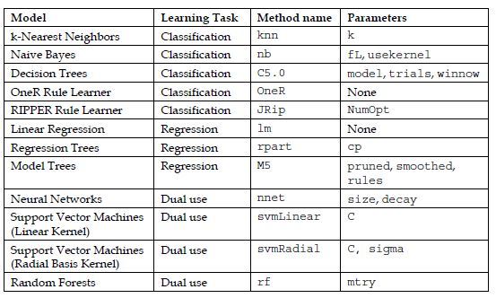

- 최적의 후보자를 구별하기 위해 모델을 평가하는 기준은 무엇인가?
- 최신 기법, 패키지를 사용해 볼 것인가?

## SVM (support vector machine)

- 서포트 벡터머신은 서로 다른 분류에 속한 데이터 간에 간격이 최대가 되는 선(또는 평면)을 찾아 이를 기준으로 데이터를 분류하는 모델임

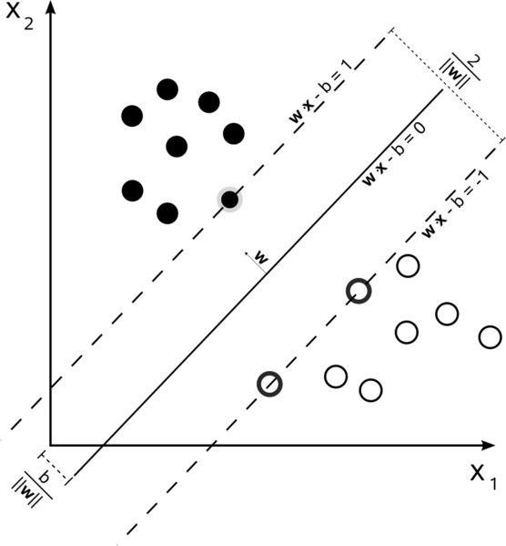

  - 서포트 벡터 머신은 각 분류에 속하는 데이터로부터 같은 간격으로, 그리고 최대로 멀리 떨어진 선 또는 평면을 찾음
  - 이러한 선 또는 평면을 최대 여백 초평면(Maximum Margin Hyperplane) 이라고 하고, 이 평면이 분류를 나누는 기준이 됨
  - 하지만, 모든 데이터를 항상 초평면으로 나눌 수 있는 것은 아님
  - 아래 왼쪽의 경우, 곡선 기준을 통해 평면을 찾을 수 없기 때문에 주어진 데이터를 적절한 고차원으로 옮긴 뒤 변환된 차원에서 서포트 벡터 머신을 사용해 초평면을 찾는 방식을 사용하는데 이를 커널 트릭이라고 함

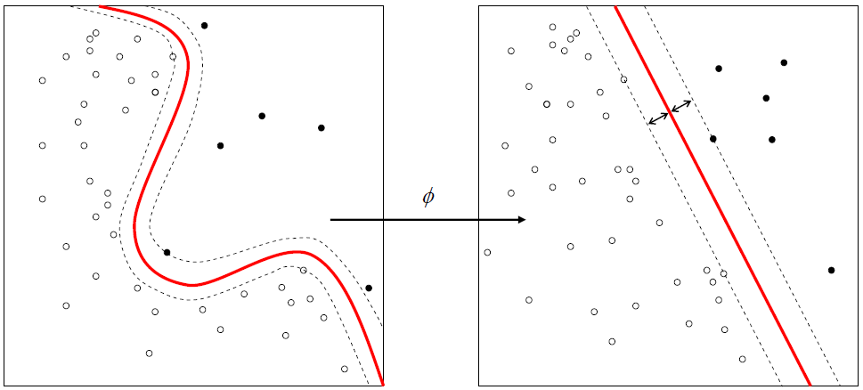

  - 커널 트릭에서는 실제로 데이터를 고차원으로 변환하는 대신 고차원에서 벡터 간 내적 계산을 했을 때와 같은 값을 반환하는 함수들을 사용한다.
    - 이 함수들을 사용하면 마치 데이터를 고차원으로 옮긴 듯한 효과를 일으키면서도 데이터를 고차원으로 옮기는데 따른 계산 비용 증가는 피할 수 있고 .. 이러한 함수들을 커널함수라고 부른다.
    - 대표적인 커널 함수로 다항 커널(Polynomial Kernel), 가우시안 커널(Gaussian Kernel), 레이디얼 베이스 함수(Radial Basis Function Kernel) 이 있음
    - 또한 이들 커널 함수는 커널 파라미터를 갖고, 이 파라미터를 조정함으로써 최적화를 할 수 있다.
    - 여기서는 Radial Basis Function Kernel 함수를 사용하고, tuneLength = 9를 통해 Cost 파라미터 C (제약을 위반하는 비용을 명시하는 수임 ) 값의 범위 c(0.25, 0.5, 1, 2, 4, 8, 16, 32, 64) 에서의 성능을 표시함으로써 적절한 파라미터값을 찾는 과정을 보여 줄 것이다.
  - SVM 의 장점은
  - 범주나 수치 예측 문제에 대해 사용할 수 있음
  - 노이즈 데이터에 영향을 크게 받지 않고 잘 과적합화되지 않음
  - 신경망보다 사용하기 쉽다.
  - 높은 정확도로 인기가 높음
  - SVM의 단점은
  - 최적의 모델을 찾기 위해 커널과 모델에서 매개변수의 여러 가지 조합 테스트가 필요함
  - 특히 입력 데이터셋이 예제 개수와 속성의 수가 많다면 훈련이 느릴 수 있음
  - 해석하기 불가능하지는 않지만, 어렵고 복잡한 블랙박스를 만든다.
- 서포트 벡터머신에 대해 보다 자세한 설명은 아래 링크를 참고
  - https://ko.wikipedia.org/wiki/%EC%84%9C%ED%8F%AC%ED%8A%B8_%EB%B2%A1%ED%84%B0_%EB%A8%B8%EC%8B%A0음

```r
# install.packages("kernlab")
suppressPackageStartupMessages({
  library(kernlab)
})
set.seed(35)
svm.tune <- train(Fate ~ Class + Sex + avg_prob
                     + I(Title=="Mr") + I(Title=="Noble") + Age + Family
                     + I(Embarked=="S") + I(Title=="Mr"&Class=="Third"),
                  data = train_batch_munged,
                  method = "svmRadial",
                  tuneLength = 9,
                  preProcess = c("center", "scale"),
                  metric = "ROC",
                  trControl = cv.ctrl)

svm.tune
```

```
## Support Vector Machines with Radial Basis Function Kernel
##
## 714 samples
##  20 predictor
##   2 classes: 'dead', 'Survived'
##
## Pre-processing: centered, scaled
## Resampling: Cross-Validated (10 fold, repeated 3 times)
## Summary of sample sizes: 643, 643, 643, 642, 643, 643, ...
## Resampling results across tuning parameters:
##
##   C      ROC   Sens  Spec  ROC SD  Sens SD  Spec SD
##    0.25  0.84  0.90  0.69  0.045   0.031    0.087
##    0.50  0.85  0.91  0.67  0.042   0.040    0.092
##    1.00  0.85  0.91  0.64  0.045   0.038    0.092
##    2.00  0.84  0.91  0.64  0.047   0.045    0.096
##    4.00  0.82  0.91  0.65  0.056   0.043    0.101
##    8.00  0.82  0.91  0.64  0.050   0.043    0.102
##   16.00  0.81  0.91  0.64  0.051   0.043    0.099
##   32.00  0.81  0.92  0.63  0.056   0.038    0.098
##   64.00  0.80  0.92  0.62  0.072   0.040    0.106
##
## Tuning parameter 'sigma' was held constant at a value of 0.12
## ROC was used to select the optimal model using  the largest value.
## The final values used for the model were sigma = 0.12 and C = 0.5.
```

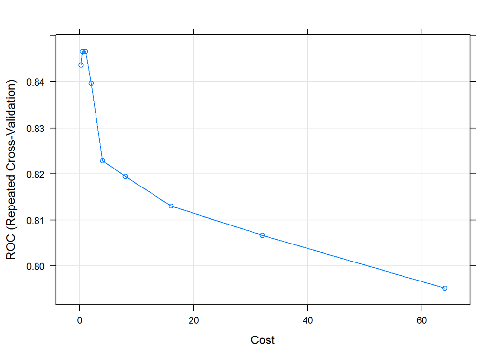

```r
plot(svm.tune)
```

```r
## 정확도
test.batch$new_predicted <- ''
test.batch$new_predicted <- predict(svm.tune, newdata=test.batch)
(svm.tune_accuracy <- sum(test.batch$new_predicted == test.batch$Fate) / NROW(test.batch$Fate) )
```

```
## [1] 0.88
```

```r
# # @@@ 제출
# # all2$PassengerId
# all2$Survived <- ''
# all2$Survived <- predict(svm.tune, newdata=all2, type="raw")
# all2$Survived <- revalue(all2$Survived, c("Survived" = 1, "dead" = 0))
# head(all2)
# submission_01 <- all2[,c("PassengerId", "Survived")]
# setwd("C:\\Users\\user\\Documents\\eda\\submission")
# getwd()
# write.csv(submission_01, file = "test_svm_tune_01.csv", row.names=FALSE)
```

## 랜덤포레스트

- 앙상블 학습 기법을 사용한 모델임
  - 앙상블 학습 : 주어진 데이터로부터 여러개의 모델을 학습한 다음, 예측 시 여러 모델의 예측 결과들을 종합해 사용하여 정확도를 높이는 기법
  - 여러 앙상블 기법 중 배깅(bagging) 이라는게 있고,
  - 하나의 학습 알고리즘을 사용해 여러 모델을 생성하는 방식임, 모델의 예측은 투표(분류의 경우)나 투표(수치 예측의 경우)을 사용해 합함
  - decision tree 모델에 추가적인 다양성을 더하기 위해 무작위 속성선택과 배깅을 접목한 것이 랜덤포레스트(random forest) 이다.
  - 랜덤포레스트(random forest) 장점
    - 대부분 문제에 잘 수행되는 다용도 모델임
    - 노이즈 데이터와 결측치 데이터를 다룰 수 있음
    - 가장 중요한 속성을 선택 할 수 있음
    - 극단적으로 큰 속성이나 예제를 가진 데이터를 다룰 수 있음
    - 배깅 쪽이 그렇듯 개별적인 약한 학습기를 훈련할 때 이전의 약한 학습기으 훈련에 의존하지 않기 때문에 훈련 과정을 별렬화시킬 수 있음
  - 단점으로는,
    - decision tree 와 달리 모델이 쉽게 해석되지 않음 (원리를 제3자에게 설명하기 어려움)
    - 데이터에 대한 모델을 조절하는 많은 작업이 필요함
- 보다 자세한 랜덤포레스트에서 대해서는 아래 링크를 확인
  - https://ko.wikipedia.org/wiki/%EB%9E%9C%EB%8D%A4_%ED%8F%AC%EB%A0%88%EC%8A%A4%ED%8A%B8

```r
## 중요변수를 확인해 보고자 함
# install.packages("randomForest")
suppressPackageStartupMessages({
  library(randomForest)
})
names(train_batch_munged)
```

```
##  [1] "Fate"            "Sex"             "Boat.dibs"       "Age"             "Title"           "SibSp"           "Parch"           "Class"
##  [9] "Deck"            "Side"            "Fare"            "Fare.pp"         "Embarked"        "Family"          "Survived"        "avg_prob"
## [17] "family_id"       "maybe_parent"    "maybe_child"     "avg_parent_prob" "avg_child_prob"
```

```r
### title 표현식에서 에러가 남
# rf.tune_temp <- randomForest(Fate ~ Class + Sex + avg_prob
#                      + I(Title=="Mr") + I(Title=="Noble") + Age + Family
#                      + I(Embarked=="S") + I(Title=="Mr"&Class=="Third")
#                      , data = train_batch_munged, importance=TRUE)

rf.tune_temp <- randomForest(Fate ~ Class + Sex + avg_prob
                     + Age + Family + Title
                     , data = train_batch_munged, importance=TRUE)

importance(rf.tune_temp)
```

```
##          dead Survived MeanDecreaseAccuracy MeanDecreaseGini
## Class    12.3    13.91                   18               19
## Sex      16.9     6.40                   19               31
## avg_prob 15.6    26.05                   31               74
## Age       4.5    17.92                   17               34
## Family   15.4     0.35                   14               16
## Title    17.6    15.02                   24               40
```

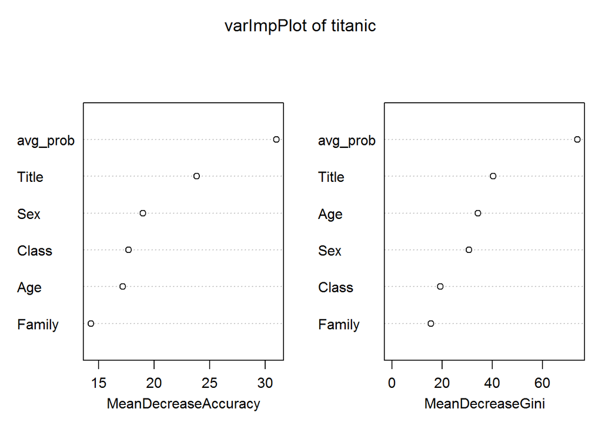

```r
varImpPlot(rf.tune_temp, main="varImpPlot of titanic")
```

정확도 측면(MeanDecreaseAccuracy) 과 노드 불순도 개선(MeanDecreaseGini) 측면에서 변수 중요도를 확인할 수 있음

```r
## 랜덤포레스트 파라미터 최적화
rf.grid <- data.frame(.mtry = c(2, 3)) ## mtry : 노드를 나눌 기준을 정할 때 고려할 변수의 수
set.seed(35)
rf.tune <- train(Fate ~ Class + Sex + avg_prob
                     + I(Title=="Mr") + I(Title=="Noble") + Age + Family
                     + I(Embarked=="S") + I(Title=="Mr"&Class=="Third") ,
                 data = train_batch_munged,
                 method = "rf",
                 metric = "ROC",
                 tuneGrid = rf.grid,
                 trControl = cv.ctrl)

## 정확도
test.batch$new_predicted <- ''
test.batch$new_predicted <- predict(rf.tune, newdata=test.batch)
(rf.tune_accuracy <- sum(test.batch$new_predicted == test.batch$Fate) / NROW(test.batch$Fate) )
```

```
## [1] 0.88
```

```r
# # # @@@ 제출
# # all2$PassengerId
# all2$Survived <- ''
# all2$Survived <- predict(rf.tune, newdata=all2, type="raw")
# all2$Survived <- revalue(all2$Survived, c("Survived" = 1, "dead" = 0))
# head(all2)
# submission_01 <- all2[,c("PassengerId", "Survived")]
# setwd("C:\\Users\\user\\Documents\\eda\\submission")
# getwd()
# write.csv(submission_01, file = "test_rf.tune_01.csv", row.names=FALSE)
```

## adaboosting

- Boosting 방식의 알고리즘
  - 약한 모델을 좀 더 추가해 임의의 경계 값에 대한 성능을 향상 시키는 개념
  - 엄청한 학습 시간과 파리미터 서치에 소요되는 시간과 노력을 감수해야 함
  - 하지만, Bagging 보다는 boosting 쪽 성능이 좋다고 알려져 있음

First up is `boosting`. I can instruct train to fit a stochastic boosting model for the binary response Fate using the adapackage and a range of values for each of three tuning parameters. Concretely, when fitting a model using train with method=”ada”, one has three levers to tweak: `iter` (number of boosting iterations, default=50), `maxdepth` (depth of trees), and `nu` (shrinkage parameter, default=1). Create a data frame with these three variables as column names and one row per tuning variable combination, and you’re good to go. Here is just one example of a tuning grid for ada:

```r
## note the dot preceding each variable
# install.packages("ada")
suppressPackageStartupMessages({
  library(ada)
})
ada.grid <- expand.grid(.iter = c(50, 100),
                        .maxdepth = c(4, 8),
                        .nu = c(0.1, 1))
```

Specify method=”ada” and tuneGrid=ada.grid in train

```r
### 여기서 많은 연산 시간을 필요로 함 , 잠시 닫아 둠
# install.packages("doMC")
# library(doMC)    ## 리눅스머신에서 진행 시, doMC 가 사용하는 multicore 는 내부적으로 fork를 사용해 프로세스를 실행시키므로 fork를 지원하지 않는 윈도우에서는 동작하지 않는다.
# registerDoMC(cores = 6)

## 윈도우에서는
# install.packages("doParallel")
suppressPackageStartupMessages({
  library(doParallel)
})
registerDoParallel(cores=2)

set.seed(35)


# train_batch_munged[!complete.cases(train_batch_munged$Title),]

# system.time(ada.tune <- train(Fate ~ Class + Sex + avg_prob
#                      + I(Title=="Mr") + I(Title=="Noble") + Age + Family
#                      + I(Embarked=="S") + I(Title=="Mr"&Class=="Third") ,
#                       data = train_batch_munged,
#                   method = "ada",
#                   metric = "ROC",
#                   tuneGrid = ada.grid,
#                   trControl = cv.ctrl)
# )
# Error in { : task 1 failed - "object 'I.Title.....Mr..TRUE' not found"
# In addition: There were 50 or more warnings (use warnings() to see the first 50)


# system.time(ada.tune <- train(Fate ~ Class + Sex + avg_prob + Age + Family + Title ,
#                       data = train_batch_munged,
#                   method = "ada",
#                   metric = "ROC",
#                   tuneGrid = ada.grid,
#                   trControl = cv.ctrl)
# )
# Error in { :
#   task 1 failed - "객체 'Titlethe.Countess'를 찾을 수 없습니다"


system.time(ada.tune <- train(Fate ~ Class + Sex + avg_prob + Age + Family  ,
                      data = train_batch_munged,
                  method = "ada",
                  metric = "ROC",
                  tuneGrid = ada.grid,
                  trControl = cv.ctrl))
```

```
##    user  system elapsed
##    3.33    0.14  255.60
```

```r
# 아래는 리눅스 desktop 환경에서의 기록임
# 병렬처리를 하지 않는 경우는, 다음과 같은 시간이 걸림
#  사용자  시스템 elapsed
# 132.532   0.000 132.697

# 사용시 registerDoMC(cores = 5) 의 경우
#  사용자  시스템 elapsed
# 136.503   0.782  42.941

# registerDoMC(cores = 8) 의 경우
#  사용자  시스템 elapsed
# 262.851   1.867  35.355
```

- ROC (Repeated Cross-Validation)
  - $ROC = \frac{Sensitivity}{Specificity}$
  - $Sensitivity (민감도) = \frac{TP}{TP + TN}$ : 정확하게 분류한 긍정이 비율(참긍정)
  - $Specificity (특이도) = \frac{TN}{TP + FP} = 1 - Sensitivity$ : 정확하게 분류된 부정의 비율(참부정)
  - Sensitivity, Specificity 는 너무 긍정적으로 쏠린다든지 혹은 너무 부정적으로 나오는 것을 감지할 수 있게 됨
    - 각각 1에 가까울 수록 바람직하게 됨
    - 테스트의 상황에 따라 다르지만 적절한 균형이 바람직함

```r
ada.tune
```

```
## Boosted Classification Trees
##
## 714 samples
##  20 predictor
##   2 classes: 'dead', 'Survived'
##
## No pre-processing
## Resampling: Cross-Validated (10 fold, repeated 3 times)
## Summary of sample sizes: 643, 643, 643, 642, 643, 643, ...
## Resampling results across tuning parameters:
##
##   nu   maxdepth  iter  ROC   Sens  Spec  ROC SD  Sens SD  Spec SD
##   0.1  4          50   0.86  0.89  0.69  0.036   0.034    0.093
##   0.1  4         100   0.86  0.89  0.71  0.036   0.038    0.090
##   0.1  8          50   0.85  0.88  0.68  0.039   0.049    0.085
##   0.1  8         100   0.85  0.88  0.68  0.040   0.046    0.089
##   1.0  4          50   0.85  0.88  0.70  0.044   0.049    0.098
##   1.0  4         100   0.85  0.88  0.70  0.045   0.047    0.091
##   1.0  8          50   0.83  0.86  0.70  0.044   0.048    0.087
##   1.0  8         100   0.83  0.86  0.71  0.046   0.041    0.081
##
## ROC was used to select the optimal model using  the largest value.
## The final values used for the model were iter = 100, maxdepth = 4 and nu = 0.1.
```

```r
# plot(ada.tune)

## 정확도
test.batch$new_predicted <- ''
test.batch$new_predicted <- predict(ada.tune, newdata=test.batch)
(rf.tune_accuracy <- sum(test.batch$new_predicted == test.batch$Fate) / NROW(test.batch$Fate) )
```

```
## [1] 0.85
```

```r
# # # @@@ 제출
# # all2$PassengerId
# all2$Survived <- ''
# all2$Survived <- predict(ada.tune, newdata=all2, type="raw")
# all2$Survived <- revalue(all2$Survived, c("Survived" = 1, "dead" = 0))
# head(all2)
# submission_01 <- all2[,c("PassengerId", "Survived")]
# setwd("C:\\Users\\user\\Documents\\eda\\submission")
# getwd()
# write.csv(submission_01, file = "test_ada_tune_01.csv", row.names=FALSE)
```

[figure not shown]

iter = 100, maxdepth = 4 and nu = 0.1 조건에서 ROC 값이 가장 큼

# Model Evaluation

With all four models in hand, I can begin to evaluate their performance by whipping together some cross-tabulations of the observed and predicted Fate for the passengers in the test.batch data. caret makes this easy with the confusionMatrix function.

- $Accuracy = \frac{TP+TN}{TP+TN+FP+FN}$ : 전체 예측에서 (예측이 Y 이든 N 이든 무관하게) 옳은 예측의 비율
- $Kappa = \frac{accuracy-P(e)}{1-P(e)}$ : 두 평가자가 얼마나 일치하는가 .. 다시 말해 두 평가자가 우연히 일치할 확률
  - 0.6 ~ 0.8 : 괜찮은 일치도
  - 0.8 ~ 1 : 훌륭한 일치도
- $Precision = \frac{TP}{TP+FP}$ : Y로 예측된 것 중 실제로도 Y인 경우의 비율

```r
# install.packages("e1071")
suppressPackageStartupMessages({
  library(e1071)
})
## Logistic regression model
glm.pred <- predict(glm.tune.1, test.batch)
confusionMatrix(glm.pred, test.batch$Survived)   ### all arguments must have the same length 에러가 나고 있음
```

```
## Confusion Matrix and Statistics
##
##           Reference
## Prediction dead Survived
##   dead       96       12
##   Survived   13       56
##
##                Accuracy : 0.859
##                  95% CI : (0.799, 0.906)
##     No Information Rate : 0.616
##     P-Value [Acc > NIR] : 9.46e-13
##
##                   Kappa : 0.702
##  Mcnemar's Test P-Value : 1
##
##             Sensitivity : 0.881
##             Specificity : 0.824
##          Pos Pred Value : 0.889
##          Neg Pred Value : 0.812
##              Prevalence : 0.616
##          Detection Rate : 0.542
##    Detection Prevalence : 0.610
##       Balanced Accuracy : 0.852
##
##        'Positive' Class : dead
##
```

```r
## Boosted model
ada.pred <- predict(ada.tune, test.batch)  ## iter, maxdept, nu 최적화값을 활용하면 어떤가?
confusionMatrix(ada.pred, test.batch$Survived)
```

```
## Confusion Matrix and Statistics
##
##           Reference
## Prediction dead Survived
##   dead       99       17
##   Survived   10       51
##
##                Accuracy : 0.847
##                  95% CI : (0.786, 0.897)
##     No Information Rate : 0.616
##     P-Value [Acc > NIR] : 1.24e-11
##
##                   Kappa : 0.671
##  Mcnemar's Test P-Value : 0.248
##
##             Sensitivity : 0.908
##             Specificity : 0.750
##          Pos Pred Value : 0.853
##          Neg Pred Value : 0.836
##              Prevalence : 0.616
##          Detection Rate : 0.559
##    Detection Prevalence : 0.655
##       Balanced Accuracy : 0.829
##
##        'Positive' Class : dead
##
```

```r
## Random Forest model
rf.pred <- predict(rf.tune, test.batch)   ## mtry=2 같은 것을 사용하지 않을까?
confusionMatrix(rf.pred, test.batch$Survived)
```

```
## Confusion Matrix and Statistics
##
##           Reference
## Prediction dead Survived
##   dead      101       14
##   Survived    8       54
##
##                Accuracy : 0.876
##                  95% CI : (0.818, 0.92)
##     No Information Rate : 0.616
##     P-Value [Acc > NIR] : 1.41e-14
##
##                   Kappa : 0.733
##  Mcnemar's Test P-Value : 0.286
##
##             Sensitivity : 0.927
##             Specificity : 0.794
##          Pos Pred Value : 0.878
##          Neg Pred Value : 0.871
##              Prevalence : 0.616
##          Detection Rate : 0.571
##    Detection Prevalence : 0.650
##       Balanced Accuracy : 0.860
##
##        'Positive' Class : dead
##
```

```r
## SVM model
svm.pred <- predict(svm.tune, test.batch)
confusionMatrix(svm.pred, test.batch$Survived)
```

```
## Confusion Matrix and Statistics
##
##           Reference
## Prediction dead Survived
##   dead      102       14
##   Survived    7       54
##
##                Accuracy : 0.881
##                  95% CI : (0.824, 0.925)
##     No Information Rate : 0.616
##     P-Value [Acc > NIR] : 3.13e-15
##
##                   Kappa : 0.744
##  Mcnemar's Test P-Value : 0.19
##
##             Sensitivity : 0.936
##             Specificity : 0.794
##          Pos Pred Value : 0.879
##          Neg Pred Value : 0.885
##              Prevalence : 0.616
##          Detection Rate : 0.576
##    Detection Prevalence : 0.655
##       Balanced Accuracy : 0.865
##
##        'Positive' Class : dead
##
```

We can also calculate, using each of the four fitted models, the predicted probabilities for the test.batch, and use those probabilities to plot the ROC curves.

```r
# install.packages("ROCR")
suppressPackageStartupMessages({
  library(ROCR)
})
```

```r
# Logistic regression model (BLACK curve)
glm.probs <- predict(glm.tune.1, test.batch, type = "prob")  ## 5 -> 1 로 변경함
glm.ROC <- roc(response = test.batch$Survived,
                predictor = glm.probs$Survived,
                levels = levels(test.batch$Survived))
plot(glm.ROC, type="S")
```

```
##
## Call:
## roc.default(response = test.batch$Survived, predictor = glm.probs$Survived,     levels = levels(test.batch$Survived))
##
## Data: glm.probs$Survived in 109 controls (test.batch$Survived dead) < 68 cases (test.batch$Survived Survived).
## Area under the curve: 0.88
```

```r
# Area under the curve: 0.8609


## Boosted model (GREEN curve)
ada.probs <- predict(ada.tune, test.batch, type = "prob")
ada.ROC <- roc(response = test.batch$Survived,
            predictor = ada.probs$Survived,
            levels = levels(test.batch$Survived))
# plot(ada.ROC, add=TRUE, col="green")
plot(ada.ROC, add=TRUE, col="green")
```

```
##
## Call:
## roc.default(response = test.batch$Survived, predictor = ada.probs$Survived,     levels = levels(test.batch$Survived))
##
## Data: ada.probs$Survived in 109 controls (test.batch$Survived dead) < 68 cases (test.batch$Survived Survived).
## Area under the curve: 0.88
```

```r
## Area under the curve: 0.8759


## Random Forest model (RED curve)
rf.probs <- predict(rf.tune, test.batch, type = "prob")
rf.ROC <- roc(response = test.batch$Survived,
           predictor = rf.probs$Survived,
           levels = levels(test.batch$Survived))
plot(rf.ROC, add=TRUE, col="red")
```

```
##
## Call:
## roc.default(response = test.batch$Survived, predictor = rf.probs$Survived,     levels = levels(test.batch$Survived))
##
## Data: rf.probs$Survived in 109 controls (test.batch$Survived dead) < 68 cases (test.batch$Survived Survived).
## Area under the curve: 0.9
```

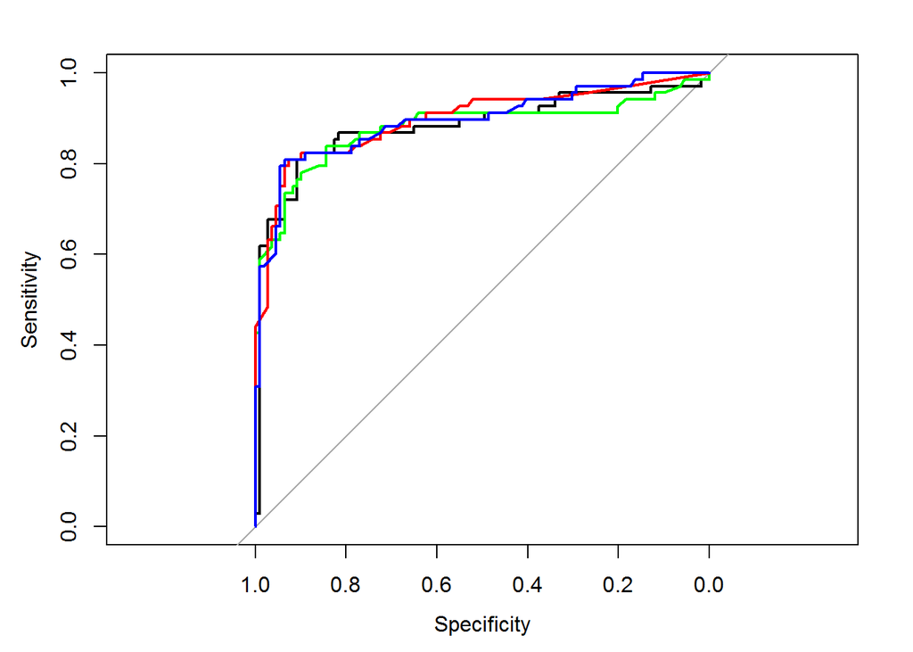

```
##
## Call:
## roc.default(response = test.batch$Survived, predictor = svm.probs$Survived,     levels = levels(test.batch$Survived))
##
## Data: svm.probs$Survived in 109 controls (test.batch$Survived dead) < 68 cases (test.batch$Survived Survived).
## Area under the curve: 0.9
```

```r
## Area under the curve: 0.8713


## SVM model (BLUE curve)
svm.probs <- predict(svm.tune, test.batch, type = "prob")
svm.ROC <- roc(response = test.batch$Survived,
            predictor = svm.probs$Survived,
            levels = levels(test.batch$Survived))
plot(svm.ROC, add=TRUE, col="blue")
```

```r
# Area under the curve: 0.8077
```

실제 문서상에 있던 plot

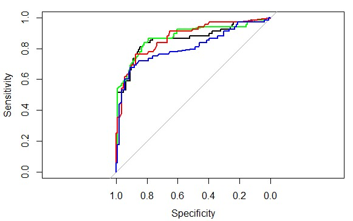

- ROC 커브
  - 거짓긍정(긍정으로 잘못 예측한) 값에 따른 참긍정 비율
  - 2차 세계대전 중 진짜신호와 거짓 알림을 구별하기 위해 개발했다고 함

AUC 값은 아래와 같은 방법으로 구할 수 있음 `unlist(rf.ROC@y.values)`

The following R script uses caret function resamples to collect the resampling results, then calls the dotplot function to create a visualization of the resampling distributions. I’m typically not one for leaning on a single metric for important decisions, but if you have been looking for that one graph which sums up the performance of the four models, this is it.

```r
cv.values <- resamples(list(Logit = glm.tune.1, Ada = ada.tune,
                            RF = rf.tune, SVM = svm.tune))
cv.values
```

```
##
## Call:
## resamples.default(x = list(Logit = glm.tune.1, Ada = ada.tune, RF = rf.tune, SVM = svm.tune))
##
## Models: Logit, Ada, RF, SVM
## Number of resamples: 30
## Performance metrics: ROC, Sens, Spec
## Time estimates for: everything, final model fit
```

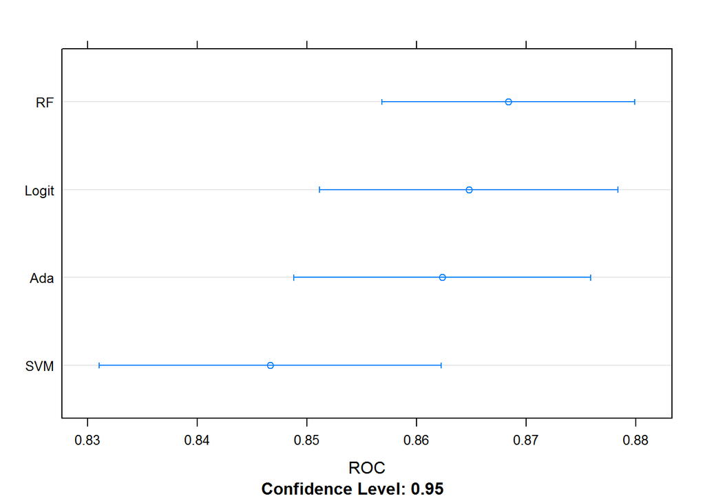

```r
dotplot(cv.values, metric = "ROC")
```

The next graph (my last, scout’s honor) compares the four models on the basis of ROC, sensitivity, and specificity. Here, sensitivity (“Sens” on the graph) is the probability that a model will predict a Titanic passenger’s death, given that the passenger actually did perish. Think of sensitivity in this case as the true perished rate. Specificity (“Spec”), on the other hand, is the probability that a model will predict survival, given that the passenger actually did survive. Simply put, all four models were better at predicting passenger fatalities than survivals, and none of them are significantly better or worse than the other three. Of the four, if I had to pick one, I’d probably put my money on the logistic regression model. alt text

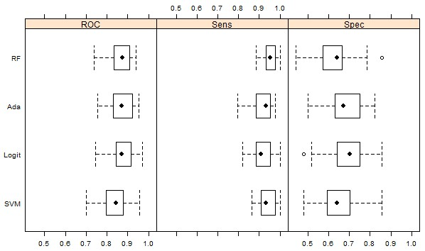

Let me reiterate the point I made in the disclaimer, way up at the top of this tl;dr page: This journey, paved with text and graphs, was never intended to reveal a path to discovery of the best model for predicting the fate of the passengers referenced in the Titanic data set. I sought only to demonstrate use of a subset of the tools ??? methods and software (R in this case) ??? a data scientist can employ in pursuit of a binary classification model.